# datavis-R course project

yufanyin

# Start up

yufan_yin_week0: 9.9. - 15.9.2020

Also see in the page to my course diary: https://yufanyin.github.io/datavis-R/

and the repository: https://github.com/yufanyin/datavis-R

## .1 Describe my dataset

**Structure of the data**

```r
learning2019 <- read.csv(file = "D:/Users/yinyf/datavis-R/week0/learning2019.csv", stringsAsFactors = TRUE)
str(learning2019)
```

```
## 'data.frame':    218 obs. of  17 variables:
##  $ 锘縞luster     : int  3 2 1 1 3 1 2 2 1 3 ...
##  $ unref          : num  4 2 3 2 3 ...
##  $ deep           : num  3.5 4.25 3.75 4.25 3.25 3.5 4.25 4.25 4 4 ...
##  $ orga           : num  3.33 3 4.33 3.67 2.67 ...
##  $ blocks         : num  3.33 3.67 3.67 3 3.67 ...
##  $ procrastination: num  3.25 4.25 3.75 2.5 4.25 3.5 3.5 4.25 3.25 2.5 ...
##  $ perfectionism  : num  3.67 3.33 3.33 2.67 2.33 ...
##  $ innateability  : num  1 1.5 3 1.5 2.5 2 2 1 2.5 1 ...
##  $ ktransforming  : num  4 3.67 3.67 3.33 4 ...
##  $ productivity   : num  1.25 2 1.25 2.25 2.25 2.5 3 2.25 2.25 3.75 ...
##  $ no             : int  1 2 3 4 5 6 7 8 9 10 ...
##  $ gender         : int  2 2 2 2 2 2 2 2 2 2 ...
##  $ faculty        : int  2 8 5 9 2 6 4 4 4 9 ...
##  $ studentstatus  : int  1 1 1 1 1 1 1 1 1 3 ...
##  $ studylength    : int  39 51 3 3 15 3 3 3 3 3 ...
##  $ writingcourse  : int  2 3 4 0 0 11 0 0 44 35 ...
##  $ monthsamel     : int  2 2 NA 0 NA 2 4 NA 3 2 ...
```

**The aim of the study** is to investigate the interrelationships between the approaches to learning and conceptions of academic writing among international university students. Altogether 218 international students of the university participated in the study in 2018 and 2019. Students were divided into homogeneous groups based on their Z scores on the three approaches to learning. Then we compare mean differences and ANOVA results between the profiles.

**The explanation of some columns** are as follows. Each of them was average value of 2-4 questions in 5-point Likert scale (1= totally disagree, 5 = fully agree).

- “unref”: relying on memorisation in the learning process, lacking the reflective approach to studying and applying the fragmented knowledge base.
- “deep”: comprehending the intentional content, using evidence and integrating with previous knowledge.
- “orga”: time management, study organisation, effort management and concentration.
- “blocks”: the inability to write productively whose reason is not intellectual capacity or literary skills.
- “procrastination”: failing to start or postponing tasks like preparing for exams and doing homework.
- “perfectionism”: setting overly high standards, pursuing flawlessness, and evaluating one’s behavior critically.
- “innateability”: writing is a skill which “is determined at birth” or “cannot be taught or developed”.
- “ktransforming”: (knowledge transforming) using writing for developing knowledge and generating new ideas and in the reflective and dialectic processes.
- “productivity”: (sense of productivity) part of self-efficacy in writing.

## .2 My previous experience in R

- I understand the basics of data wrangling.
- I learned to use R to conduct anayses such as clustering and classification **not very proficiently**.

Because I attended the course “Introduction to Open Data Science” (HYMY-909, 5 cr) last autumn. Here are the link to my github repository:

https://github.com/yufanyin/IODS-project

and my course diary:

https://yufanyin.github.io/IODS-project/

## .3 Expectations for this course

- To learn practical data visualization skills using R and the ggplot2 -library. I know little in data visualization.
- To learn about good data visualization and avoid bad/incorrect operation.
- To produce rich, accurate and concise visualizations **using my own data**. I have found the proper method to deal with my own data and conducted using SPSS. Attending this course can help me produce better visualizations, which will benefit me a lot when I submit my FIRST article at the end of this year.

# Week 1 Exercises

yufan_yin_week1: 16.9. - 21.9.2020

Also see in the page to my course diary: https://yufanyin.github.io/datavis-R/

(It is the habit because of another course.)

## Exercise 1

```r
# Create a vector named my_vector. It should have 7 numeric elements.
my_vector <- c(20, 14, 18, 14, 10, 16, 16)

# Print your vector
my_vector
```

```
## [1] 20 14 18 14 10 16 16
```

```r
# Calculate the minimum, maximum, and median values of your vector
summary(my_vector)
```

```
##    Min. 1st Qu.  Median    Mean 3rd Qu.    Max.
##   10.00   14.00   16.00   15.43   17.00   20.00
```

```r
# Print "The median value is XX"
mean_exercise1 <- mean(my_vector) # Output from functions can be saved to objects
paste("The median value is ", mean_exercise1) # Use the paste() function to print the object with text
```

```
## [1] "The median value is  15.4285714285714"
```

## Exercise 2

```r
# Create another vector named my_vector_2. It should have the elements of my_vector divided by 2.
my_vector_2 <- my_vector/2 # Access individual elements of a vector with indices
my_vector_2
```

```
## [1] 10  7  9  7  5  8  8
```

```r
# Create a vector named my_words. It should have 7 character elements.
my_words <- c("swan", "goose", "mallard", "blue_tit", "philomelos", "sparrow", "gull")

# Combine my_vector and my_words into a data frame.
df <- data.frame(my_vector, my_words)
df
```

```
##   my_vector   my_words
## 1        20       swan
## 2        14      goose
## 3        18    mallard
## 4        14   blue_tit
## 5        10 philomelos
## 6        16    sparrow
## 7        16       gull
```

```r
# Show the structure of the data frame.
str(df)
```

```
## 'data.frame':    7 obs. of  2 variables:
##  $ my_vector: num  20 14 18 14 10 16 16
##  $ my_words : chr  "swan" "goose" "mallard" "blue_tit" ...
```

## Exercise 3

```r
library(tidyverse)
# Use the head() function to print the first 3 rows of your data frame.
head(df) #How to print the first 3 rows instead of 5?
```

```
##   my_vector   my_words
## 1        20       swan
## 2        14      goose
## 3        18    mallard
## 4        14   blue_tit
## 5        10 philomelos
## 6        16    sparrow
```

```r
# Create a new variable to the data frame which has the values of my_vector_2 (remember to save the new variable to the data frame object).
pair <- c(my_vector_2)
pair
```

```
## [1] 10  7  9  7  5  8  8
```

```r
df2 <- data.frame(df,pair)
df2
```

```
##   my_vector   my_words pair
## 1        20       swan   10
## 2        14      goose    7
## 3        18    mallard    9
## 4        14   blue_tit    7
## 5        10 philomelos    5
## 6        16    sparrow    8
## 7        16       gull    8
```

```r
# Use filter() to print rows of your data frame greater than the median value of my_vector.
df2 %>% filter(df2 > mean(my_vector))
```

```
##   my_vector my_words pair
## 1        20     swan   10
## 2        18  mallard    9
## 3        16  sparrow    8
## 4        16     gull    8
```

# Week 2 Exercises

yufan_yin_week2: 23.9. - 28.9.2020

Also see in the page to my course diary: https://yufanyin.github.io/datavis-R/

## Exercise 1

### 1.1 Loading libraries and suppressing any output messages in the chunk settings

Create a new code chunk where you load the tidyverse package. In the chunk settings, suppress any output messages.

### 1.2 Reading the data

```r
df
```

```
## # A tibble: 60 x 4
##    group gender score1 score2
##    <int> <chr>   <dbl> <chr>
##  1     2 F        18.7 14.7563711082321
##  2     1 M        20.1 15.1463059324341
##  3     2 F        17.4 19.0025387614538
##  4     1 M        18.7 15.5693261509451
##  5     2 F        18.5 16.7322250273729
##  6     1 999      16.9 16.4511010915052
##  7     2 M        20.4 15.1008590050657
##  8     1 F        20.3 15.191041952879
##  9     1 F        19.4 13.9717194882152
## 10     2 M        21.2 22.6918520246433
## # ... with 50 more rows
```

There is something to fix in three of the variables. Explore the data and describe what needs to be corrected.

**Hint**: You can use e.g. str(), distinct(), and summary() to explore the data.

```r
str(df)
```

```
## tibble [60 x 4] (S3: tbl_df/tbl/data.frame)
##  $ group : int [1:60] 2 1 2 1 2 1 2 1 1 2 ...
##  $ gender: chr [1:60] "F" "M" "F" "M" ...
##  $ score1: num [1:60] 18.7 20.1 17.4 18.7 18.5 ...
##  $ score2: chr [1:60] "14.7563711082321" "15.1463059324341" "19.0025387614538" "15.5693261509451" ...
```

```r
summary(df)
```

```
##      group        gender              score1         score2
##  Min.   :1.0   Length:60          Min.   :14.17   Length:60
##  1st Qu.:1.0   Class :character   1st Qu.:16.85   Class :character
##  Median :1.5   Mode  :character   Median :17.61   Mode  :character
##  Mean   :1.5                      Mean   :17.89
##  3rd Qu.:2.0                      3rd Qu.:19.01
##  Max.   :2.0                      Max.   :21.53
```

```r
distinct(df)
```

```
## # A tibble: 60 x 4
##    group gender score1 score2
##    <int> <chr>   <dbl> <chr>
##  1     2 F        18.7 14.7563711082321
##  2     1 M        20.1 15.1463059324341
##  3     2 F        17.4 19.0025387614538
##  4     1 M        18.7 15.5693261509451
##  5     2 F        18.5 16.7322250273729
##  6     1 999      16.9 16.4511010915052
##  7     2 M        20.4 15.1008590050657
##  8     1 F        20.3 15.191041952879
##  9     1 F        19.4 13.9717194882152
## 10     2 M        21.2 22.6918520246433
## # ... with 50 more rows
```

## Exercise 2

### 2.1 Tidying data

Make the corrections you described above.

```r
df <- df %>%
  mutate(gender = na_if(gender, 999)) # recode 999 to NA (missing)
  df$score2 <- as.numeric(df$score2) # convert a character vector to a numeric vector
```

### 2.2 Counting observations by grouping variables

Count observations by group and gender. Arrange by the number of observations (ascending).

```r
df %>%
  count(group, gender) %>% # count() is a combination of group_by() and tally()
  arrange(desc(n)) %>% # OR: "%>% floor()"?
  arrange(group)
```

```
## # A tibble: 6 x 3
##   group gender     n
##   <int> <chr>  <int>
## 1     1 M         14
## 2     1 F         13
## 3     1 <NA>       3
## 4     2 F         15
## 5     2 M         14
## 6     2 <NA>       1
```

## Exercise 3

### 3.1 Creating a new variable: the difference between scores

Create a new variable, **score_diff**, that contains the difference between score1 and score2.

```r
df$score_diff <- df$score1 - df$score2
```

### 3.2 Computing the means: using summarise() to take multiple variables in one go

Compute the means of score1, score2, and score_diff.

**Hint**: Like mutate(), summarise() can take multiple variables in one go.

```r
df %>%
  summarise(score1_mean = mean(df$score1), score2_mean = mean(df$score2), score_diff_mean = mean(df$score_diff))
```

```
## # A tibble: 1 x 3
##   score1_mean score2_mean score_diff_mean
##         <dbl>       <dbl>           <dbl>
## 1        17.9        16.1            1.82
```

### 3.3 Computing the means by grouping variable

Compute the means of score1, score2, and score_diff **by gender**.

```r
grouped_df <- df %>%
  group_by(gender)

grouped_df %>%
  summarise(score1_mean = mean(df$score1), score2_mean = mean(df$score2), score_diff_mean = mean(df$score_diff))
```

```
## # A tibble: 3 x 4
##   gender score1_mean score2_mean score_diff_mean
##   <chr>        <dbl>       <dbl>           <dbl>
## 1 F             17.9        16.1            1.82
## 2 M             17.9        16.1            1.82
## 3 <NA>          17.9        16.1            1.82
```

```r
  # the results look strange but I do not know what went wrong
```

## Exercise 4

### 4.1 Creating an x-y scatter plot

Using ggplot2, create a scatter plot with score1 on the x-axis and score2 on the y-axis.

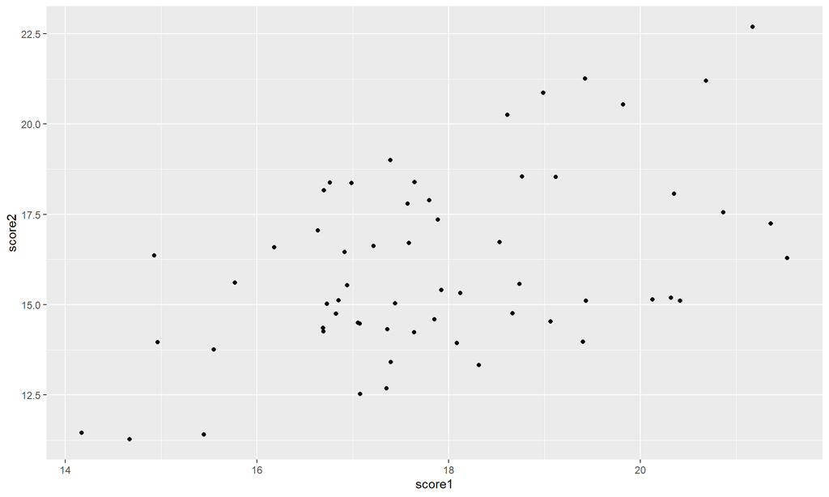

```r
df %>%
  ggplot(aes(score1, score2)) + # x = score1, y = Sscore2
  geom_point()
```

### 4.2 Setting colour based on grouping variable, figure width and height

Continuing with the previous plot, colour the points based on gender.

Set the output figure width to 10 and height to 6.

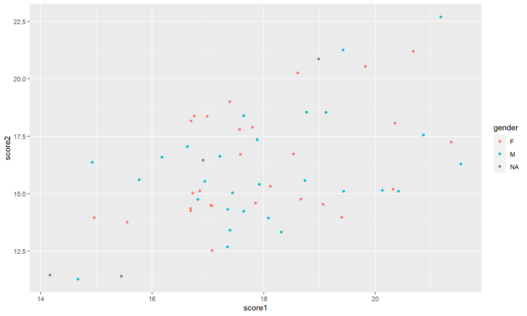

```r
df %>%
  ggplot(aes(score1, score2, color = gender)) + # x = score1, y = score2
  geom_point()
```

## Exercise 5

**Note:** I did this part in another rmd file named ‘index’.

see: https://github.com/yufanyin/datavis-R/blob/master/index.Rmd

### 5.1 Metadata section

Add the author (your name) and date into the metadata section. Create a table of contents.

### 5.2 Knitting

Knit your document to HTML by changing `html_notebook` to `html_document` in the metadata, and pressing Knit.

See the results in my course diary: https://yufanyin.github.io/datavis-R/